# Lab 2

Advanced Data Visualization

Author

Allen Choi

# Instructions

**Create a Quarto file for ALL Lab 2 (no separate files for Parts 1 and 2).**

- Make sure your final file is carefully formatted, so that each analysis is clear and concise.
- Be sure your knitted `.html` file shows **all** your source code, including any function definitions.

# Part One: Identifying Bad Visualizations

If you happen to be bored and looking for a sensible chuckle, you should check out these [Bad Visualisations](https://badvisualisations.tumblr.com/). Looking through these is also a good exercise in cataloging what makes a visualization good or bad.

## Dissecting a Bad Visualization

   Each country has a varying level of percentage of people who believe that vaccines are safe. Depending on the region which each country is in, there is an overall difference in percentage on average as well. Basically, percentage of vaccine acceptance depends on country as well as region.
2. List the variables that appear to be displayed in this visualization. *Hint: Variables refer to columns in the data.*

   The variables that appear to be displayed is % of vaccine acceptance, country, and region.
3. Now that you’re versed in the grammar of graphics (e.g., `ggplot`), list the *aesthetics* used and which *variables* are mapped to each.

   x: percentage of people who believe that vaccines are safe

   y: country

   color: region
4. What type of graph would you call this? Meaning, what `geom` would you use to produce this plot?

   I would call it a scatterplot, but with jittered points for each country, so probably geom_jitter().
5. Provide at least four problems or changes that would improve this graph. *Please format your changes as bullet points!*
   - It is hard to compare countries in different regions with each other
   - The y-axis has no meaning
   - The legend is unnecessary since the labels are already there
   - There is too much going on and it takes too much time to understand the message

## Improving the Bad Visualization

The data for the Wellcome Global Monitor 2018 report can be downloaded at the following site: [https://wellcome.ac.uk/reports/wellcome-global-monitor/2018](https://wellcome.org/sites/default/files/wgm2018-dataset-crosstabs-all-countries.xlsx)

There are two worksheets in the downloaded dataset file. You may need to read them in separately, but you may also just use one if it suffices.

```r
library(tidyverse)
library(here)
library(plotly)
library(ggridges)
data_dict <- readxl::read_xlsx(here("wgm2018-dataset-crosstabs-all-countries.xlsx"),
                               sheet = 3)
data <- readxl::read_xlsx(here("wgm2018-dataset-crosstabs-all-countries.xlsx"),
                               sheet = 2) |>
  select(c(WP5, Q25, Regions_Report))
data_dict <- data_dict[1, 3] |>
  rename(country = `Variable Type & Codes*`) |>
  separate_wider_delim(country, delim = ",", names_sep = "-")

data_dict <- data_dict[1, 1:ncol(data_dict)-1]

country_code <- data.frame(t(data_dict)) |>
  separate_wider_delim(cols = `t.data_dict.`,
                       delim = "=",
                       names_sep = "-") |>
  rename(code = `t.data_dict.-1`,
         country = `t.data_dict.-2`) |>
  mutate(code = as.numeric(code))

final <- data |>
  drop_na() |>
  left_join(country_code, by = join_by(WP5 == code)) |>
  select(-WP5) |>
  mutate(Q25 = case_when(
    Q25 == 1 ~ 1,
    Q25 == 2 ~ 1,
    .default = 0
  )) |>
  group_by(country) |>
  summarize(percentage = sum(Q25) / n())

regions <- data |>
  select(WP5, Regions_Report) |>
  distinct(WP5, Regions_Report) |>
  left_join(country_code, by = join_by(WP5 == code)) |>
  mutate(region = case_when(
    Regions_Report %in% c(1, 2, 4, 5) ~ "Sub-Saharan Africa",
    Regions_Report %in% c(3, 13) ~ "Middle East / North Africa",
    Regions_Report %in% c(6, 7, 8) ~ "Americas",
    Regions_Report %in% c(9, 10, 11, 12) ~ "Asia",
    Regions_Report %in% c(15, 16, 17) ~ "Europe",
    Regions_Report %in% c(14) ~ "Former Soviet Union",
    .default = "Other"
  )) |>
  select(country, region)
```

6. Improve the visualization above by either re-creating it with the issues you identified fixed OR by creating a new visualization that you believe tells the same story better.

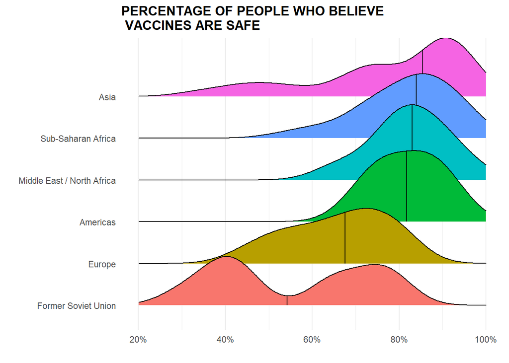

```r
final |>
  left_join(regions, by = join_by(country == country)) |>
  filter(region != "Other") |>
  mutate(region = factor(region,
                         levels = c("Former Soviet Union", "Europe", "Americas",
                                    "Middle East / North Africa", "Sub-Saharan Africa", "Asia"))) |>
  ggplot(aes(y = region, x = percentage,
             fill = region,
             group = region)) +
  stat_density_ridges(quantiles = 2, quantile_lines = 2) +
  theme_minimal() +
  ggtitle("PERCENTAGE OF PEOPLE WHO BELIEVE \n VACCINES ARE SAFE") +
  theme(legend.position = "none",
        panel.grid.minor.y = element_blank(),
        panel.grid.major.y = element_blank(),
        title = element_text(face = "bold")) +
  labs(y = "",
       x = "") +
  scale_x_continuous(limits = c(.2, 1), labels = scales::label_percent())
```

# Part Two: Broad Visualization Improvement

The full Wellcome Global Monitor 2018 report can be found here: https://wellcome.ac.uk/sites/default/files/wellcome-global-monitor-2018.pdf. Surprisingly, the visualization above does not appear in the report despite the citation in the bottom corner of the image!

## Second Data Visualization Improvement

**For this second plot, you must select a plot that uses maps so you can demonstrate your proficiency with the `leaflet` package!**

7. Select a data visualization in the report that you think could be improved. Be sure to cite both the page number and figure title. Do your best to tell the story of this graph in words. That is, what is this graph telling you? What do you think the authors meant to convey with it?

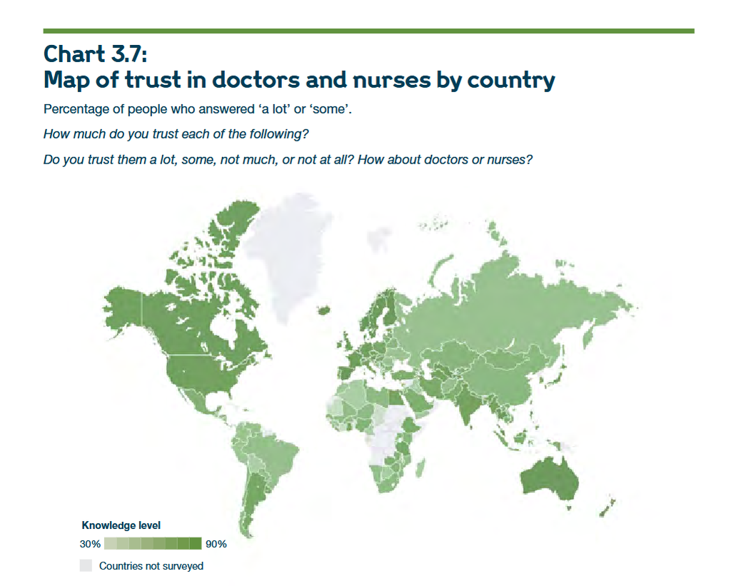

   The map I want to use is on page 65 and is Chart 3.7: Map of trust in doctors and nurses by country. The story the visualization is trying to tell is that certain regions/countries in the world have lower trust in their doctors than other countries. For example, countries in Europe/America have higher overall trust in their doctors/nurses than countries in Asia/Eastern Europe.
8. List the variables that appear to be displayed in this visualization.
   - Countries
   - Trust level for doctors/nurses
9. Now that you’re versed in the grammar of graphics (ggplot), list the aesthetics used and which variables are specified for each.
   - x: Countries
   - color: Trust level
10. What type of graph would you call this?

    A map with a gradient scale for trust level for each country
11. List all of the problems or things you would improve about this graph.

    The legend title is misleading as legend title states “knowledge level” when the actual data is talking about how much they trust their doctors/nurses. Also, it is hard to tell the difference between countries when the gradient is between light green and dark green.
12. Improve the visualization above by either re-creating it with the issues you identified fixed OR by creating a new visualization that you believe tells the same story better.

```r
library(leaflet)
library(rnaturalearth)
data <- readxl::read_xlsx(here("wgm2018-dataset-crosstabs-all-countries.xlsx"),
                               sheet = 2) |>
  select(c(WP5, Q11E))

map_data <- data |>
  mutate(Q11E = as.character(Q11E)) |>
  group_by(WP5) |>
  mutate(Q11E = case_when(
    Q11E == 1 ~ 1,
    Q11E == 2 ~ 1,
    .default = 0
  )) |>
  summarize(percent = (sum(Q11E) / n())) |>
  left_join(country_code, by = join_by(WP5 == code)) |>
  mutate(country = case_when(
    country == "United States" ~ "United States of America",
    .default = country
  ))


country_map_info <- ne_countries(returnclass = "sf")
country_map_info <- country_map_info |>
  inner_join(map_data, by = join_by(name == country)) |>
  mutate(percent = percent * 100,
         percent = round(percent, digits = 2))

colors <- colorNumeric(palette = "YlGnBu", domain = country_map_info$percent)
country_map_info |>
  leaflet() |>
  addTiles() |>
  addPolygons(color = colors(country_map_info$percent),
              weight = 2,
              popup = paste0(
                "Country:", " ", country_map_info$name, " <br> ",
                "Percent:", " ", country_map_info$percent),
              label = paste0(
                "Percent:", " ", country_map_info$percent, "%"),
              fillOpacity = 1) |>
  addLegend(pal = colors, values = country_map_info$percent,
            title = "Percent Trust in Doctors/Nurses <br> (Response = 'A lot'/'Some')",
            opacity = 1)
```

[interactive chart not shown]

## Third Data Visualization Improvement

**For this third plot, you must use one of the other `ggplot2` extension packages mentioned this week (e.g., `gganimate`, `plotly`, `patchwork`, `cowplot`).**

13. Select a data visualization in the report that you think could be improved. Be sure to cite both the page number and figure title. Do your best to tell the story of this graph in words. That is, what is this graph telling you? What do you think the authors meant to convey with it?

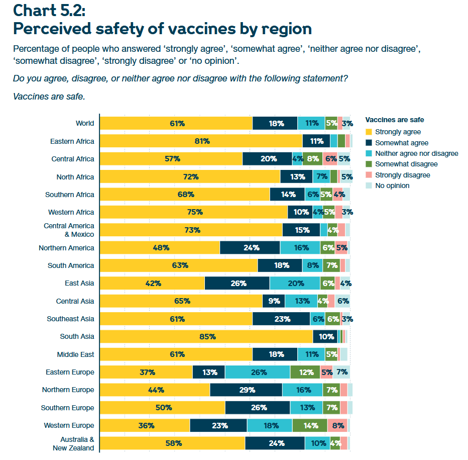

    The visualization I selected is on page 110 and titled Chart 5.2: Perceived Safety of Vaccines by region. I think the graph is trying to tell us that different regions of the world have extremely different views on vaccine safety. Some areas have extremely positive views while other regions have relatively negative views.
14. List the variables that appear to be displayed in this visualization.
    - Region
    - Vaccine Safety Opinion
15. Now that you’re versed in the grammar of graphics (ggplot), list the aesthetics used and which variables are specified for each.
    - x: Region
    - y: Vaccine Safety
    - fill: Vaccine Safety
16. What type of graph would you call this?

I would call it a stacked bar plot but normalized so that each region adds up to 100%.

13. List all of the problems or things you would improve about this graph.
1. The graph from top to bottom isn’t organized in any way, which makes it hard to identify any patterns
2. There is way too much information within each bar, so only selecting a specific opinion (Strongly Agree) would help a lot
3. No x-axis
13. Improve the visualization above by either re-creating it with the issues you identified fixed OR by creating a new visualization that you believe tells the same story better.

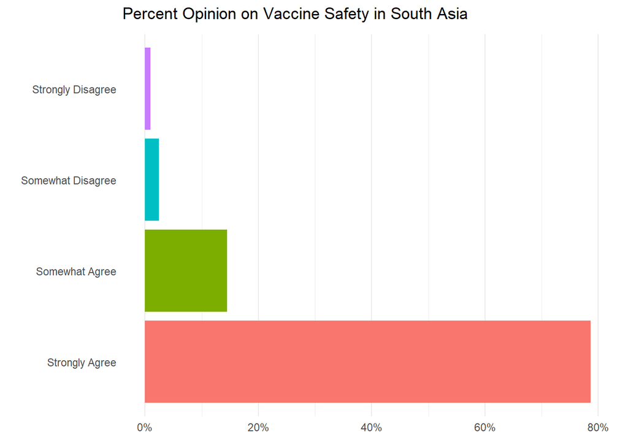

```r
library(gganimate)
library(gifski)
data <- readxl::read_xlsx(here("wgm2018-dataset-crosstabs-all-countries.xlsx"),
                               sheet = 2) |>
  select(c(Regions_Report, Q25))

data_dict <- readxl::read_xlsx(here("wgm2018-dataset-crosstabs-all-countries.xlsx"),
                               sheet = 3)
data_dict <- data_dict[57, 3] |>
  rename(region = `Variable Type & Codes*`) |>
  separate_wider_delim(region, delim = ",", names_sep = "-")

data_dict <- data_dict[1, 1:ncol(data_dict)-1]

region_codes <- data.frame(t(data_dict)) |>
  separate_wider_delim(cols = `t.data_dict.`,
                       delim = "=",
                       names_sep = "-") |>
  rename(code = `t.data_dict.-1`,
         region = `t.data_dict.-2`) |>
  mutate(code = as.numeric(code))

cleaned_data <- data |>
  drop_na() |>
  mutate(Q25 = case_when(
    Q25 == 1 ~ "Strongly Agree",
    Q25 == 2 ~ "Somewhat Agree",
    Q25 == 4 ~ "Somewhat Disagree",
    Q25 == 5 ~ "Strongly Disagree",
    .default = ""
  )) |>
  left_join(region_codes, by = join_by(Regions_Report == code)) |>
  filter(region != "Not assigned") |>
  group_by(region) |>
  summarize(strongly_agree = sum(Q25 == "Strongly Agree") / n(),
            somewhat_agree = sum(Q25 == "Somewhat Agree") / n(),
            somewhat_disagree = sum(Q25 == "Somewhat Disagree") / n(),
            strongly_disagree = sum(Q25 == "Strongly Disagree") / n()) |>
  arrange(desc(strongly_agree))

arranged <- cleaned_data$region
plot <- cleaned_data |>
  pivot_longer(cols = !region) |>
  mutate(name = case_when(
    name == "strongly_agree" ~ "Strongly Agree",
    name == "somewhat_agree" ~ "Somewhat Agree",
    name == "somewhat_disagree" ~ "Somewhat Disagree",
    name == "strongly_disagree" ~ "Strongly Disagree"
  )) |>
  mutate(name = factor(name,
                       levels = c("Strongly Agree", "Somewhat Agree",
                                  "Somewhat Disagree", "Strongly Disagree")),
         region = factor(region, levels = arranged)) |>
  ggplot(aes(y = name, x = value, fill = name)) +
  geom_bar(stat = "identity") +
  theme_minimal() +
  theme(legend.position = "none",
        panel.grid.minor.y = element_blank(),
        panel.grid.major.y = element_blank()) +
  labs(y = "", x = "") +
  scale_x_continuous(limits = c(0, 0.8), labels = scales::label_percent())

final <- plot + transition_states(region)
final +
  ggtitle("Percent Opinion on Vaccine Safety in {closest_state}")
```